# Aiden Kutney STA 106, Homework 2, R Portion

# R part 1

# 1a

```
## [1] 0.9853726
```

As seen above the power of the test is 0.9853726

# 1b

```
##
##      Balanced one-way analysis of variance power calculation
##
##               k = 5
##               n = 13.55073
##               f = 0.6341055
##       sig.level = 0.05
##           power = 0.99
##
## NOTE: n is number in each group
```

Smallest sample size would be 14

# 1c

```
##
##      Balanced one-way analysis of variance power calculation
##
##               k = 5
##               n = 17.18512
##               f = 0.6341055
##       sig.level = 0.01
##           power = 0.99
##
## NOTE: n is number in each group
```

Smallest sample size would be 18

# 1d

When the F statistic is very large we expect the power of the test to be large. The power of a test is the probability of rejecting the null hypothesis when the alternative is true. When the F stat is very large, the p value is very small therefore it does not border the alpha level.

If the p value is border line with alpha level, the power of test is lower. In general the farther away the p value is from the alpha level (on the less than side of the alpha level), the higher the power of tests.

# 2a

```
##    Estimate Lower Bound Upper Bound
##    74.41176  -419.19622   568.01975
```

Above is ci for stomach mean - bronchus mean.

# 2b

This CI suggests a non significant difference in means since the CI contains zero -> thus meaning that were are 95% confident the difference of stomach mean - bronchus mean is between -419.2 and 568.0

#2c

```
##    Estimate Lower Bound Upper Bound
##    208.6176   -199.4183    616.6536
```

Above is the ci for colon mean - 1/2 stomach mean - 1/2 bronchus mean

# 2d

Since the ci contains zero, there is no significant difference in survival time means. We are 95% confident that the difference of means between the colon cancer group and group stomach and bronchus cancer is -199.4183 and 616.6536.

# 3a

null: means are all equal

alt: one or more mean is different from the others

```
##             Df Sum Sq Mean Sq F value Pr(>F)
## group        2  3.766  1.8832   4.846 0.0159 *
## Residuals   27 10.492  0.3886
## ---
## Signif. codes:  0 '***' 0.001 '**' 0.01 '*' 0.05 '.' 0.1 ' ' 1
```

The above p value is 0.0159. Since p value < alpha(.05) reject null hypothesis. That means one or more mean is different from the others.

# 3b

```
## green$group: ctrl
## [1] -0.041
## ------------------------------------------------------------
## green$group: trt1
## [1] -0.412
## ------------------------------------------------------------
## green$group: trt2
## [1] 0.453
```

Above is gamma i’s of the green data.

# 3c

The power is a probability that we correctly reject the hypothesized fact that the average weight of the plant of each treatment and control group is equal when it is indeed false.

# 3d

.90 is the probability that if the groups means are equal we will no reject the null.

# 4a

```
## [1] 0.8503337
```

The power is above for .10 alpha level.

# 4b

```
##
##      Balanced one-way analysis of variance power calculation
##
##               k = 5
##               n = 16.61295
##               f = 0.5683947
##       sig.level = 0.05
##           power = 0.99
##
## NOTE: n is number in each group
```

# 4c

To increase power of the test, we can increase sample size.

# 4d

ci of: 1/2 control mean + 1/2 treatment1 mean - treatment2 mean

```
##    Estimate Lower Bound Upper Bound
##  -0.6795000  -1.1748775  -0.1841225
```

Above is 95% CI.

# 4e

# Book Part 2

# 1a

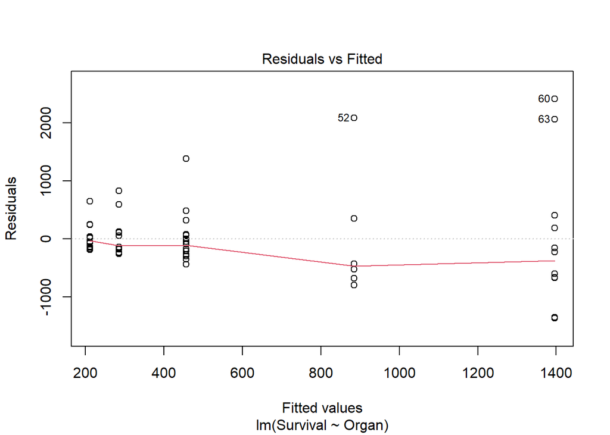

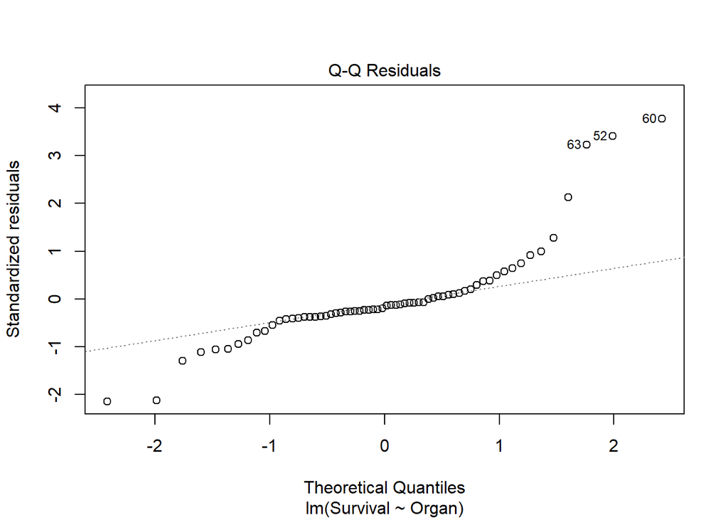

Yes 2 assumptions of ANOVA have been broken, normal distribution for residuals and equal variance of residuals between groups which are both not present in this data.

# 1b

```
## named integer(0)
```

```
## named integer(0)
```

There are no cases of outliers when using the standardized approach with alpha = 0.01

# 1c

```
##
##  Shapiro-Wilk normality test
##
## data:  ei
## W = 0.8068, p-value = 9.981e-08
```

The P value is stated above

# 1d

```
## [1] 0.003271089
```

The above number is the p value for the Brown-Forsythe test.

# 1e

Since the outlier producing method did not indicate any outliers were present, we did not remove any outliers.

# 2a

```
## [1] 0.18883532 0.20782805 0.02187559
```

In order, the lambdas above are obtained from methods: PPCC, Shapiro-Wilkes, and Log-Likelihood. We will use shapiro-wilkes since that is what is suggested in HW problem

# 2b

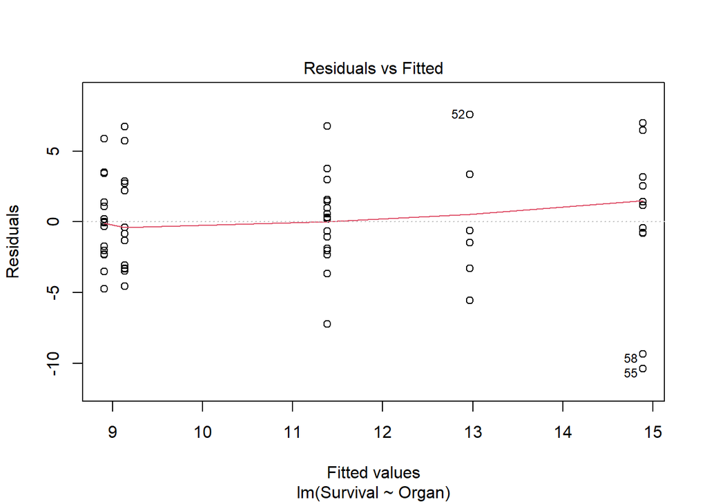

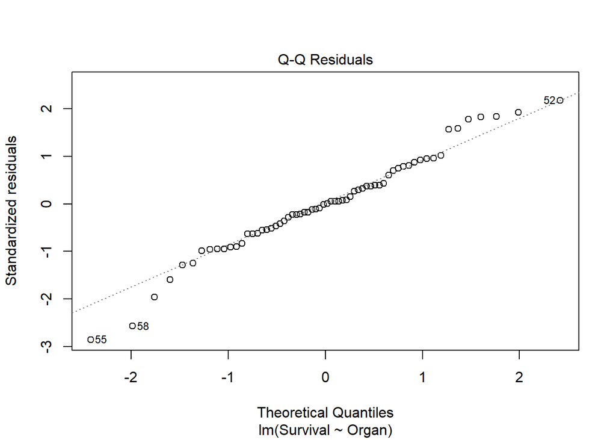

The above is the transformed model

Below is the non transformed model with original data

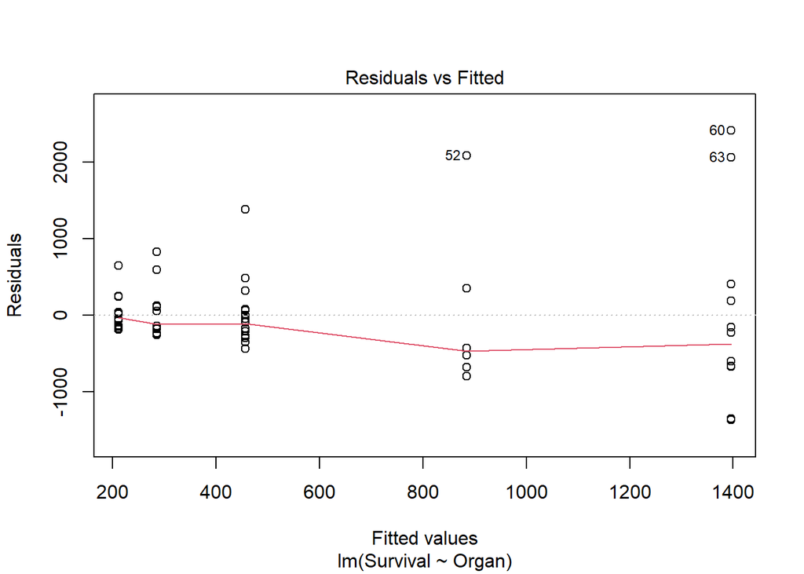

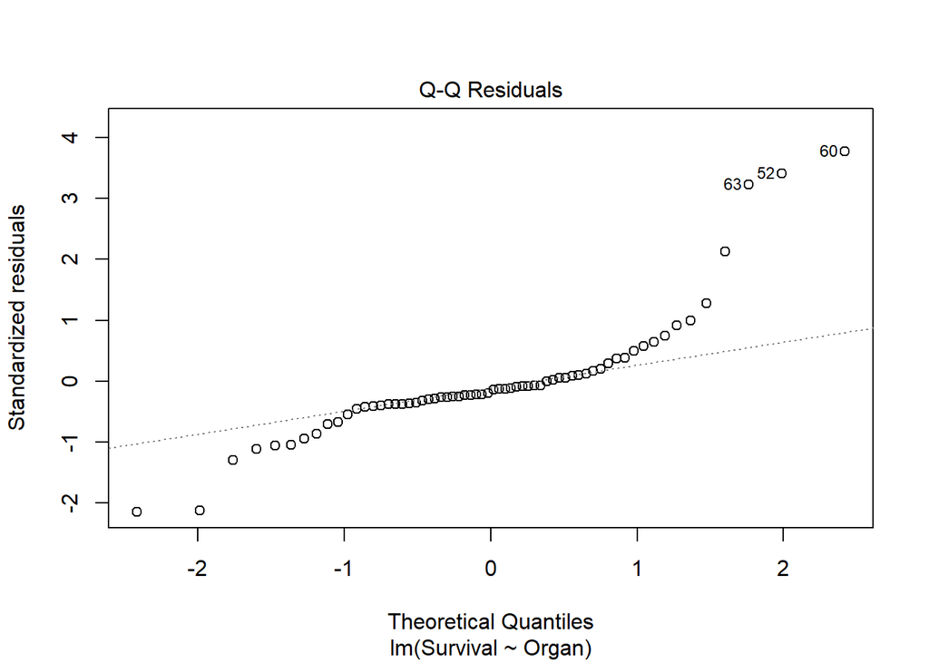

As can be seen, the transformed data has equal variance between groups and a normal distribution

# 2c

```
##
##  Shapiro-Wilk normality test
##
## data:  ei
## W = 0.97623, p-value = 0.2525
```

Here is p value of SW for transformed data model

# 2d

```
## [1] 0.3184981
```

Above is the p value for BF for transformed data model

# 2e

### Transformed Data SFA

Hypothesis:

null: all means survival for organ cancer type is equal

alt: one or more mean survival is different from another mean

```
##             Df Sum Sq Mean Sq F value   Pr(>F)
## Organ        4  311.9   77.96   5.369 0.000936 ***
## Residuals   59  856.8   14.52
## ---
## Signif. codes:  0 '***' 0.001 '**' 0.01 '*' 0.05 '.' 0.1 ' ' 1
```

```
##             Df   Sum Sq Mean Sq F value   Pr(>F)
## Organ        4 11535761 2883940   6.433 0.000229 ***
## Residuals   59 26448144  448274
## ---
## Signif. codes:  0 '***' 0.001 '**' 0.01 '*' 0.05 '.' 0.1 ' ' 1
```

P value listed above

I believe that the transformed data gives us a more reliable p value due to having more normalized residuals and more equal variance of residuals between groups.

# 3a

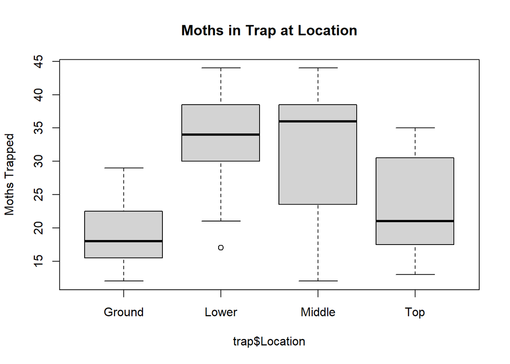

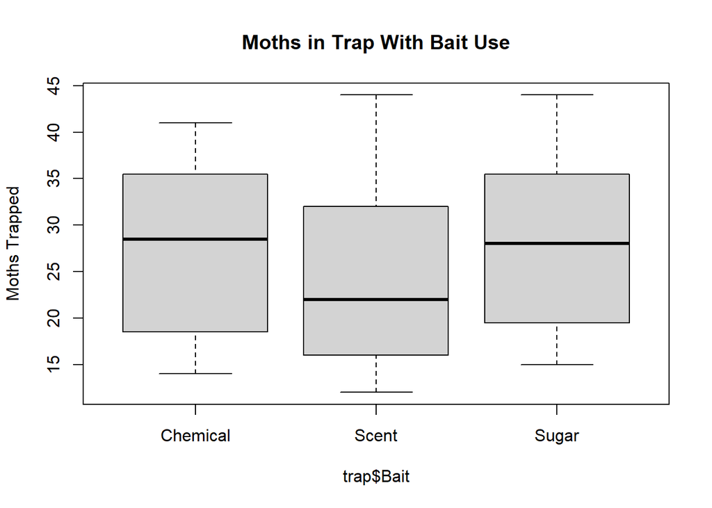

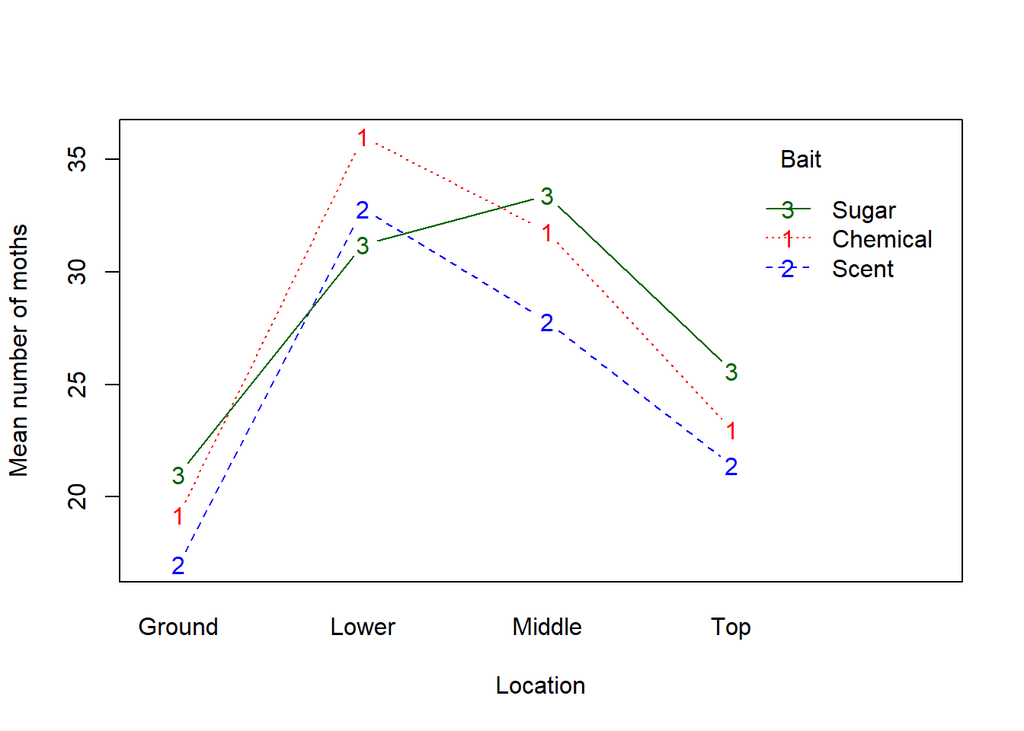

# 3b

```
##   Location     Moth
## 1   Ground 19.06667
## 2    Lower 33.33333
## 3   Middle 31.00000
## 4      Top 23.33333
```

# 3c

```
##       Bait  Moth
## 1 Chemical 27.50
## 2    Scent 24.75
## 3    Sugar 27.80
```

# 3d

```
##    Location     Bait Moth
## 1    Ground Chemical 19.2
## 2     Lower Chemical 36.0
## 3    Middle Chemical 31.8
## 4       Top Chemical 23.0
## 5    Ground    Scent 17.0
## 6     Lower    Scent 32.8
## 7    Middle    Scent 27.8
## 8       Top    Scent 21.4
## 9    Ground    Sugar 21.0
## 10    Lower    Sugar 31.2
## 11   Middle    Sugar 33.4
## 12      Top    Sugar 25.6
```

# 3e

```
##             Df Sum Sq Mean Sq F value   Pr(>F)
## Location     3   1981   660.5   11.34 6.46e-06 ***
## Residuals   56   3262    58.2
## ---
## Signif. codes:  0 '***' 0.001 '**' 0.01 '*' 0.05 '.' 0.1 ' ' 1
```

As seen above the p value for location is very low indicating the null hypothesis (all means for moth are =) is rejected. That means that the number of moths trapped via location are different.

# 4a

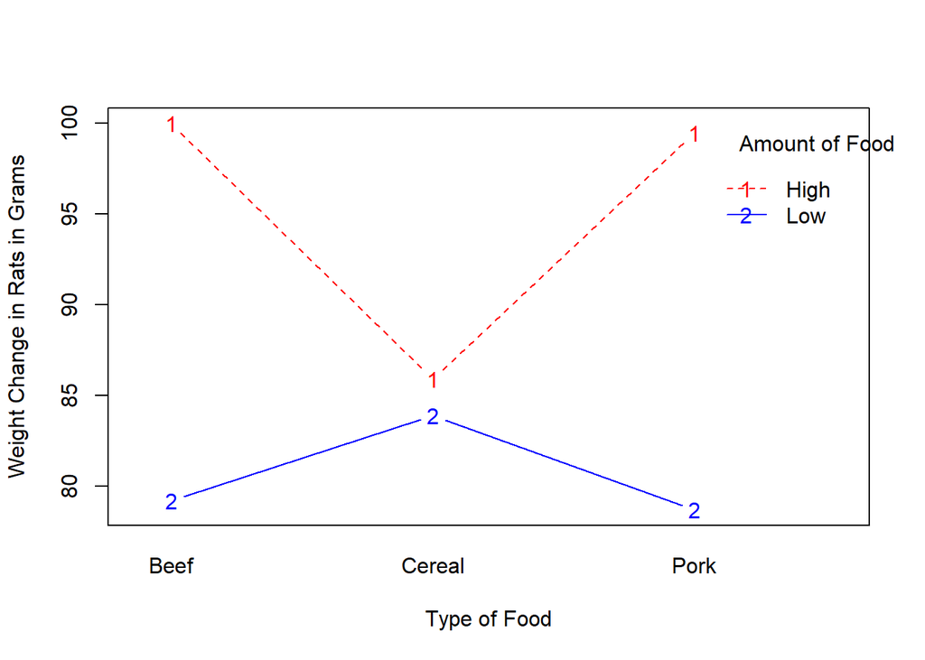

As amount of food is high, it leads to higher weight change in rats. However, High amounts of pork and beef lead to especially high weight change

# 4b

I am going to assume this is for weight means by type.

```r
aggregate(Weight ~ Type, data=rat, mean)
```

```
##     Type Weight
## 1   Beef   89.6
## 2 Cereal   84.9
## 3   Pork   89.1
```

# 4c

```r
aggregate(Weight~Amount, data=rat, mean)
```

```
##   Amount   Weight
## 1   High 95.13333
## 2    Low 80.60000
```

# 4d

```r
aggregate(Weight ~ Amount + Type, data = rat, mean)
```

```
##   Amount   Type Weight
## 1   High   Beef  100.0
## 2    Low   Beef   79.2
## 3   High Cereal   85.9
## 4    Low Cereal   83.9
## 5   High   Pork   99.5
## 6    Low   Pork   78.7
```

# 4e

```r
result <- aov(Weight ~ Type, data = rat)
summary(result)
```

```
##             Df Sum Sq Mean Sq F value Pr(>F)
## Type         2    267   133.3   0.477  0.623
## Residuals   57  15932   279.5
```

Since the p value is large for this SFA comparing mean weight change between groups in the food Type category, we can say that there is not a significant change in weight change means. Therefore weight gain is not different for type of food.

### R Code Appendix (will automatically list all code used)

```r
give.me.power <-  function(ybar,ni,MSE,alpha){
  a = length(ybar) # Finds a
  nt = sum(ni) #Finds the overall sample size
  overall.mean = sum(ni*ybar)/nt # Finds the overall mean
  phi = (1/sqrt(MSE))*sqrt( sum(ni*(ybar - overall.mean)^2)/a) #Finds the books value of phi
  phi.star = a *phi^2 #Finds the value of phi we will use for R
  Fc = qf(1-alpha,a-1,nt-a) #The critical value of F, use in R's function
  power = 1 - pf(Fc, a-1, nt-a, phi.star)# The power, calculated using a non-central F
  return(power)
}

cancer <- read.csv("./Cancer.csv")
group.means = by(cancer$Survival,cancer$Organ,mean)
group.nis = by(cancer$Survival,cancer$Organ,length)
the.model = lm(Survival ~ Organ, data = cancer)
anova.table = anova(the.model)
MSE = anova.table[2,3]

give.me.power(group.means,group.nis,MSE,0.05)
library(pwr)
overall.mean = sum(group.means*group.nis)/sum(group.nis)
effect.size = sqrt( sum( group.nis/sum(group.nis) *(group.means -overall.mean)^2 )/MSE)
pwr.anova.test(k = 5, f = effect.size, sig.level = 0.05, power = 0.99)


pwr.anova.test(k = 5, f = effect.size, sig.level = 0.01, power = 0.99)

give.me.CI = function(ybar,ni,ci,MSE,multiplier){
  if(sum(ci) != 0 & sum(ci !=0 ) != 1){
    return("Error - you did not input a valid contrast")
  } else if(length(ci) != length(ni)){
    return("Error - not enough contrasts given")
  }
  else{
    estimate = sum(ybar*ci)
    SE = sqrt(MSE*sum(ci^2/ni))
    CI = estimate + c(-1,1)*multiplier*SE
    result = c(estimate,CI)
    names(result) = c("Estimate","Lower Bound","Upper Bound")
    return(result)
  }
}
#Stomach, Bronchus, Colon, Ovary, Breast
#5        2         3      4      1     (alphabetical order of Organ)

t.value = qt(1-0.05/2, sum(group.nis) - length(group.nis))
ci <- c(0, -1, 0, 0, 1) #stomach mean - bronchus mean
give.me.CI(group.means,group.nis,ci,MSE,t.value)


#Stomach, Bronchus, Colon, Ovary, Breast
#5        2         3      4      1     (alphabetical order of Organ)

t.value = qt(1-0.05/2, sum(group.nis) - length(group.nis))
ci <- c(0, -.5, 1, 0, -.5) #colon mean - 1/2stomach mean - 1/2bronchus mean
give.me.CI(group.means,group.nis,ci,MSE,t.value)
green <- read.csv('./Green.csv')
result <- aov(weight ~ group, data = green)
summary(result)
group.means = by(green$weight, green$group,mean)
gammai <- group.means - mean(group.means)
gammai
group.means = by(green$weight,green$group,mean)
group.nis = by(green$weight,green$group,length)
the.model = lm(weight ~ group, data = green)
anova.table = anova(the.model)
MSE = anova.table[2,3]

give.me.power(group.means,group.nis,MSE,0.10)

overall.mean = sum(group.means*group.nis)/sum(group.nis)
effect.size = sqrt( sum( group.nis/sum(group.nis) *(group.means -overall.mean)^2 )/MSE)
pwr.anova.test(k = 5, f = effect.size, sig.level = 0.05, power = 0.99)
t.value = qt(1-0.05/2, sum(group.nis) - length(group.nis))
ci <- c(.5, .5, -1)
give.me.CI(group.means,group.nis,ci,MSE,t.value)
cancer <- read.csv("./Cancer.csv")
model = lm(Survival ~ Organ,data = cancer)
plot(model, which=1)
plot(model, which=2)
nt = nrow(cancer)
a = length(unique(cancer$Organ)) #
t.cutoff= qt(1-.01/(2*nt), nt-a)
rij = rstandard(model)
CO.rij = which(abs(rij) > t.cutoff)
CO.rij

cancer$ei = model$residuals
SSE = sum(cancer$ei^2) #Sums and squares the errors (finds SSE)
MSE = SSE/(nt-a) #Finds MSE
eij.star = model$residuals/sqrt(MSE)
t.cutoff= qt(1-.01/(2*nt), nt-a)
CO.eij = which(abs(eij.star) > t.cutoff)
CO.eij
ei = model$residuals
the.SWtest = shapiro.test(ei)
the.SWtest

library(car)
the.BFtest = leveneTest(ei~ Organ, data=cancer, center=median)
p.val = the.BFtest[[3]][1]
p.val

library(EnvStats)

L1 =boxcox(model ,objective.name = "PPCC",optimize = TRUE)$lambda
L2 = boxcox(model ,objective.name = "Shapiro-Wilk",optimize = TRUE)$lambda
L3 = boxcox(cancer$Survival,objective.name = "Log-Likelihood",optimize = TRUE)$lambda
lambdas = c(L1, L2, L3)
lambdas

YT = (cancer$Survival^(L2)-1)/L2
t.data = data.frame(Survival = YT, Organ = cancer$Organ)
t.model = lm(Survival ~ Organ,data = t.data)
plot(t.model, which=1)
plot(t.model, which=2)
plot(model, which=1)
plot(model, which=2)
ei = t.model$residuals
the.SWtest = shapiro.test(ei)
the.SWtest
the.BFtest = leveneTest(ei~ Organ, data=t.data, center=median)
p.val = the.BFtest[[3]][1]
p.val
result <- aov(Survival ~ Organ, data = t.data)
summary(result)
result <- aov(Survival ~ Organ, data = cancer)
summary(result)
trap <- read.csv('./Traps.csv')
boxplot(trap$Moth ~ trap$Location, main = "Moths in Trap at Location",ylab = "Moths Trapped")
boxplot(trap$Moth ~ trap$Bait, main = "Moths in Trap With Bait Use",ylab = "Moths Trapped")
interaction.plot(
  x.factor = trap$Location,
  trace.factor = trap$Bait,
  response = trap$Moth,
  fun = mean,                 # mean is default, but you can change
  type = "b",                 # points and lines
  col = c("red", "blue", "darkgreen"),
  ylab = "Mean number of moths",
  xlab = "Location",
  trace.label = "Bait"
)
aggregate(Moth ~ Location, data=trap, mean)
aggregate(Moth ~ Bait, data=trap, mean)
aggregate(Moth ~ Location + Bait, data = trap, mean)
result <- aov(Moth ~ Location, data = trap)
summary(result)
rat <- read.csv("./rat.csv")
interaction.plot(
  x.factor = rat$Type,
  trace.factor = rat$Amount,
  response = rat$Weight,
  fun = mean,                 # mean is default, but you can change
  type = "b",                 # points and lines
  col = c("red", "blue", "darkgreen"),
  ylab = "Weight Change in Rats in Grams",
  xlab = "Type of Food",
  trace.label = "Amount of Food"
)
aggregate(Weight ~ Type, data=rat, mean)
aggregate(Weight~Amount, data=rat, mean)
aggregate(Weight ~ Amount + Type, data = rat, mean)
result <- aov(Weight ~ Type, data = rat)
summary(result)
```